# Locus Lead prototype

Can a distance rule count an Analysis’s loci without an LD panel? The results of opengwas/opengwasdb#62’s prototype

## Question and result

`n_hits_*`, the Top-Hit Counts in a Store’s `analyses.tsv`, count an Analysis’s associations past each significance threshold. They mix two things: how many loci an Analysis has, and how densely its variant axis is typed. A Reference-Completed Store and a HapMap3-density Store give the same locus very different hit counts. opengwas/opengwasdb#62 proposed a second count beside them, `n_loci_*`, that counts **Locus Leads**: one lead per locus, chosen by a pruning rule that uses genetic distance in centimorgans (cM) as a stand-in for linkage disequilibrium (LD) clumping, so that neither a build nor a query needs an LD reference panel. This report gathers what the prototype tickets found when they held that rule against real plink2 clumping.

**Result.** The owner has dropped Locus Leads: `n_loci_*` will come from LD clumping at Store build time instead. No pruning rule agrees with plink2 clumping lead by lead, a plain base-pair (bp) window saturates in the most polygenic Analyses, the rules that keep up split loci that clumping keeps whole, and exact clumping costs little at build time; What it means for `n_loci_*` gives the numbers.

The prototype’s code is throwaway; it lives in the engine’s `prototypes/locus_leads/` on the integration branch `orch/62-locus-leads`. Its outputs were committed under `docs/benchmark-output/locus_leads/`, and every number below is read from them at engine commit 3c2bdd9 (see Reproduce).

## The question

### The proposal

[The proposal on #62](https://github.com/opengwas/opengwasdb/issues/62) adds `n_loci_5e8`, `n_loci_5e6` and `n_loci_5e4` beside the `n_hits_*` columns, and a Locus Lead option for the Top-Hit Query. A Locus Lead is not an *independent* signal: neither this rule nor clumping is conditional analysis. The rule ranks on |z|, never on p. A float64 two-sided p is 0 from |z| ≈ 38.5, and the strongest Analyses in our Stores go well past that, so ranking on p would tie the strongest variants of a big locus.

### The ancestry-specific revision

[The revision](https://github.com/opengwas/opengwasdb/issues/62) replaced the single pedigree map of the first proposal with **ancestry-specific maps**, one per Store. LD decays faster per cM where effective population size is larger, as in African (AFR) populations, so one cM leaves less LD there than in European (EUR) ones. The revision therefore calibrates D per ancestry (EUR, AFR, East Asian or EAS, and admixed American or AMR), each on its own genotype panel, and predicts two things the prototype tested: that AFR needs a smaller D than EUR, and that the AMR map, built from admixed samples, is the least trustworthy.

### What the prototype tickets asked

The prototype tickets, each a sub-issue of #62.

| ticket | question |
| --- | --- |
| [#402](https://github.com/opengwas/opengwasdb/issues/402) | Does the comparison work end to end on one EUR Analysis? |
| [#403](https://github.com/opengwas/opengwasdb/issues/403) | Across EUR Analyses, is there a D and W that matches clumping, and does cM beat a plain bp window? |
| [#404](https://github.com/opengwas/opengwasdb/issues/404) | Is the published pyrho EUR map good enough, or does another map do better? |
| [#405](https://github.com/opengwas/opengwasdb/issues/405) | Does the method work for AFR, EAS and AMR, and with what D? |
| [#406](https://github.com/opengwas/opengwasdb/issues/406) | Is pruning cheaper than clumping, and fast enough to run per query? |
| [#409](https://github.com/opengwas/opengwasdb/issues/409) | Do locus boundaries taken from the data (peak prominence, LD blocks) beat a fixed distance? |

## Method

### The Locus Lead rule

For each Analysis, tier and chromosome, take the tier’s rows in descending |z|, with ties broken by ascending Variant Index (a row’s place in the Store Variant Table). Accept a row as a Locus Lead unless an already-accepted lead lies within **W bp and D cM** of it. D does the main work: it splits signals across a recombination hotspot, which a bp window would merge. W caps merging where cM barely moves over megabases (Mb, millions of bp), such as centromeres and inversions. With D set to infinity the rule becomes a plain bp window of width W, the **bp-only** rule, which every sweep runs as its baseline.

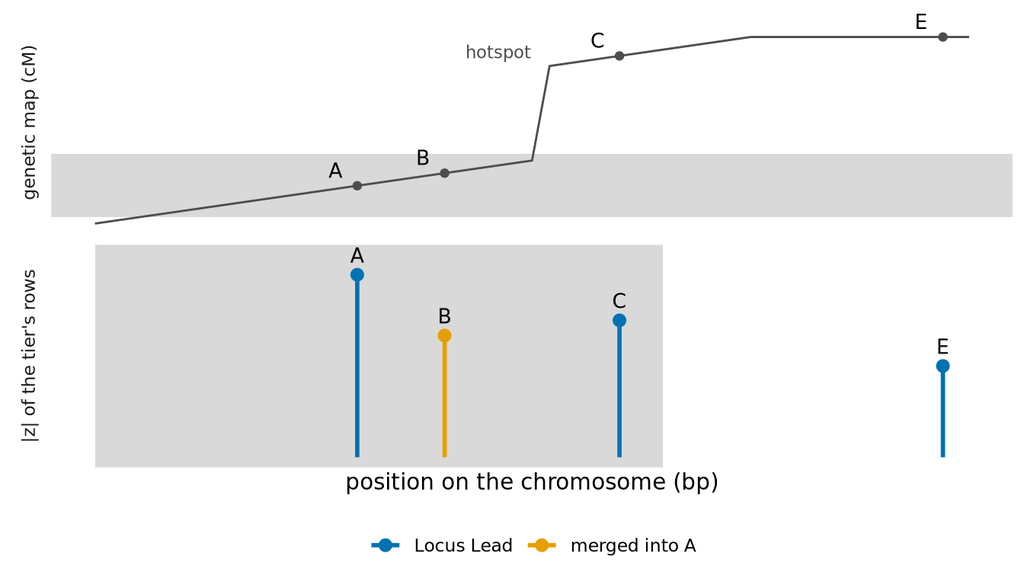

The rule on a toy chromosome. A is the strongest hit and becomes a Locus Lead. B lies within W bp and within D cM of A, so it merges into A. C lies within W bp of A, but a recombination hotspot puts it more than D cM away, so it becomes a lead. E lies within D cM of C, where cM barely moves, but more than W bp from it, so it becomes a lead too. The shaded spans are A’s D window (top) and A’s W window (bottom).

### Genetic maps

The maps are the published pyrho maps (Spence and Song, *Science Advances*): recombination maps inferred from LD in each 1000 Genomes population, so they reflect historical recombination. They were released on Zenodo (https://zenodo.org/records/11437540, archive md5 `45ebb10c4acf939ea03a3932c483f638`, checked on every load). Each ancestry’s map is the equal-weight mean of its populations’ maps. cM is interpolated linearly between map points, held flat beyond a chromosome’s ends, and left missing on a chromosome the map does not cover (X, Y and MT), never replaced by a substitute value.

The populations averaged into each ancestry’s map, with the weights each map records.

| ancestry | 1000 Genomes populations | maps averaged | weight of each |
| --- | --- | --- | --- |
| EUR | CEU, GBR, FIN, TSI, IBS | 5 | 0.200 |
| AFR | YRI, LWK, GWD, MSL, ESN, ACB, ASW | 7 | 0.143 |
| EAS | CHB, JPT, CHS, CDX, KHV | 5 | 0.200 |
| AMR | MXL, PUR, CLM, PEL | 4 | 0.250 |

The EUR mean carries two jumps that come from one population’s map each. #402 found them, and #403 measured them from the population maps:

The two single-population spikes in the pyrho EUR mean. Hits on either side of one never merge under a cM rule.

| population | map point | interval to the next point | the population’s map gains | the EUR mean keeps |
| --- | --- | --- | --- | --- |
| TSI | chr7:131,782,269 | 444 bp | 92.68 cM | 18.60 cM |
| GBR | chr1:235,056,161 | 23,295 bp | 33.58 cM | 6.76 cM |

### The reference: plink2 clumping

Clumping runs `plink2 --clump` on the HGDP+1kGP genotype panels (the Human Genome Diversity Project and 1000 Genomes samples, as gnomAD released them), split by super-population, each Analysis against its own ancestry’s panel: index p 5×10<sup>−8</sup>, a window of 10,000 kb (kilobases, thousands of bp), and r² computed unphased because the panels carry no phase. plink2 is given −log10 p computed from z, with equal values separated in the rule’s order, so both methods rank rows identically even where p underflows.

The primary threshold is **r² 0.01**; r² 0.001, the old OpenGWAS default, is reported beside it. The panels are small (EUR 771, AFR 804, EAS 817 and AMR 345 samples), and at these sizes unlinked variants reach a low r² by chance. Among variant pairs on different chromosomes in the EUR panel, 42.0% reach r² 0.001 and 1.16% reach r² 0.01. So r² 0.001 mostly measures noise at this sample size, and r² 0.01 is the reference every criterion is judged against.

### The shared set

Both methods see the same rows. Each sweep reads an Analysis’s Observed Associations at the 5×10<sup>−8</sup> tier, the rows a Top-Hit Query returns at p ≤ 5×10<sup>−8</sup> (Imputed Associations are left out), and keeps the rows matched to the panel by chromosome, position and allele set that also have a finite cM. Every other row is counted under exactly one reason (off the panel’s chromosomes, absent at its position, other alleles, ambiguous, or no cM), so none is dropped silently. An Analysis with less than 70% of its rows in the shared set is recorded and not swept.

### Two ways to judge a rule

**Per lead.** A *spurious split* is a Locus Lead that plink2 places inside a stronger index variant’s clump; a *lost signal* is a plink2 index variant that the rule merges into a stronger Locus Lead. The rates are spurious splits / Locus Leads and lost signals / plink2 index variants. #403 fixed its working criteria before it ran: at r² 0.01, spurious splits at most 10% of Locus Leads **and** lost signals at most 10% of index variants, and clearly better than bp-only at the same W (a pooled disagreement rate at most 90% of bp-only’s, and lower in at least 67% of the Analyses where the two differ).

**Per Analysis, by counts.** `n_loci_*` is one number per Analysis, so after #403 the owner decided to judge rules by counts, with the per-lead rates kept as diagnostics. The count criteria were written into #403’s output before they were computed, in this wording:

- **C1:** rank. Spearman rho(Locus Leads, r2 0.01 index variants) over the swept Analyses is >= 0.95.
- **C2:** density. For each swept Analysis, restrict the shared set to HapMap3 variants and recompute the leads at every (D, W) and bp-only; no re-clumping. Density ratio = leads(HM3) / leads(full). C2 holds when the median ratio over Analyses is in [0.8, 1.25] and its median |log2| is at most half that of the same ratio for raw row counts (rows(HM3) / rows(full)).
- **C3:** cM against bp-only, at the same W. cM adds value when its best D improves on bp-only by at least 0.01 in rho (C1) or by at least 0.1 in median |log2 density ratio| (C2), without being worse on the other by more than those margins.
- Reading of C3: at a W, C3 holds when some D improves on that W’s bp-only by at least one margin and is worse on neither by more than its margin; the D that do are listed.
- The point named: the (D, W), bp-only included, that meets C1 and C2 and has the smallest pooled share of leads lost to density, sum over Analyses of max(0, leads(full) - leads(HM3)) / sum of leads(full); the best cM point is named the same way.

HapMap3 (HM3 in the criteria) here is the list of 1,206,903 HapMap3 variants on GRCh38 (the Genome Reference Consortium’s human build 38, the assembly every Store, map and panel here uses), standing in for a sparse variant axis such as a HapMap3-density Store’s. A rule that is insensitive to variant density finds about as many loci on it as on the full shared set.

## Results by ticket

### #402: the tracer on one EUR Analysis

**Question.** Does a comparison of Locus Leads with plink2 clumping run end to end on one well-powered Analysis, with every row accounted for?

**Criteria.** The map archive’s checksum is checked before use; interpolated cM never decreases along a chromosome; off-panel rows and rows with no cM are counted, not dropped; both methods choose the same lead among ties at p = 0; a synthetic fixture splits across a hotspot and merges in a cold region; and the output reproduces. The engine’s tests check the checksum, the monotone map, the tie order and the hotspot; the committed output records every count and both rates, a re-run reproduced it byte for byte, and its row categories add up to the tier, which the extract for this page checks. **Met.**

**Result.** finngen-r13-BMI_IRN (Body mass index, inverse-rank normalized) in OGS-00003 has 55,460 Observed Associations at 5×10<sup>−8</sup> and 0 imputed. 85.6% of them are in the shared set. 45,816 rows sit in 4,055 runs of tied |z|, which is why the tie order matters even below the p = 0 range.

Where each of finngen-r13-BMI_IRN’s 55,460 tier rows went. The categories add up to the tier.

| category | rows |
| --- | --- |
| shared set | 47,457 |
| on the panel, no cM | 0 |
| off the panel’s chromosomes | 3,624 |
| absent at its position | 4,226 |
| other alleles | 55 |
| ambiguous | 98 |

Locus Leads at D 0.5 cM, W 1 Mb against plink2’s index variants, for finngen-r13-BMI_IRN.

| clumping r² | Locus Leads | index variants | agreed | spurious splits (rate) | lost signals (rate) |
| --- | --- | --- | --- | --- | --- |
| 0.01 | 569 | 742 | 512 | 57 (10.0%) | 230 (31.0%) |
| 0.001 | 569 | 415 | 269 | 300 (52.7%) | 146 (35.2%) |

At r² 0.01, 40 of the 57 spurious splits lie further than W from the stronger index variant whose clump holds them (the median distance over all of them is 1.23 Mb). That pointed at chance r² at this panel size, which #403 then measured. The tracer also found the two map spikes above.

### #403: the EUR sweep

**Question.** Across many EUR Analyses, is there a (D, W) at which Locus Leads match plink2’s r² 0.01 clumping, and does the cM condition do better than a plain bp window of the same W?

**The Analyses.** 40 Analyses were drawn with seed 403 from 7,372 EUR Analyses (by Assigned Ancestry) in the genome-wide Stores, stratified by observed 5×10<sup>−8</sup> rows and by largest |z|, with at least 5 of largest |z| ≥ 100 and 5 past the p = 0 point. 1,999 pool Analyses had no Observed Association at the tier and could not be drawn. Analyses with more than 1,000,000 observed rows were left out of the pool: GCST002047 and GCST004461, whose largest |z| are 111.2 and 359.5 (#406 found 96% and 39% of their tier rows past |z| 38, where p is close to underflowing, which looks like an artefact of their sources). 3 drawn Analyses fell under the shared-set floor (GCST90704633 67.4%, GCST90475609 61.7%, GCST90477870 0.0%), so 37 were swept: 15 with largest |z| ≥ 100. They hold 1,964,596 Observed Associations at the tier, 91.9% of them in the shared set. The grid is D ∈ {0.1, 0.25, 0.5, 1, 2.5} cM × W ∈ {0.25, 1, 2.5, 10} Mb, plus bp-only at each W.

#### The per-lead judgement: not met

**No (D, W) meets the per-lead criteria.** 0 of the 24 points qualify. The nearest, by the larger of its two rates, is D 0.1 cM, W 2.5 Mb: 32.3% spurious splits and 27.6% lost signals. The plain 2.5 Mb window gives 5.5% and 64.6%. Lost signals never fall below 27.0% anywhere on the grid. Spurious splits reach the 10% limit only at 8 points, all with W of at least 2.5 Mb, and there lost signals are at least 44.1%. A cM condition trades lost signals for spurious splits; it never gets both down.

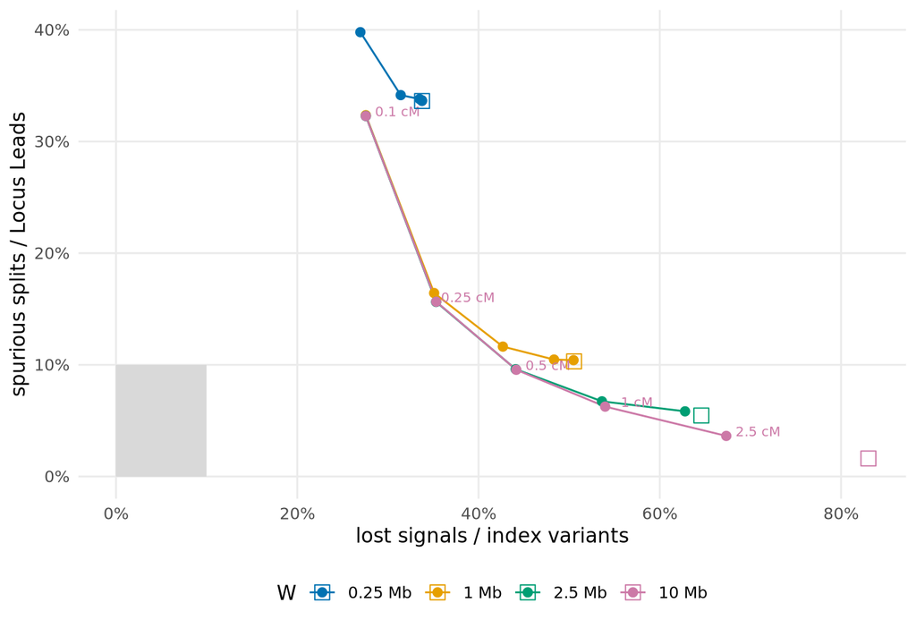

Spurious splits against lost signals, pooled over the 37 swept EUR Analyses at r² 0.01. Each line is one W; its circles are the D values, left to right from the smallest (labelled on the W 10 Mb line), and its open square is the bp-only rule. The shaded corner is where both rates meet the per-lead criteria, and no point reaches it: a smaller D buys fewer lost signals at the price of more spurious splits.

Two things made per-lead agreement the wrong yardstick for a count:

- **r² 0.01 clumping splits strong peaks into their LD shadows.** A variant with r² 0.01 to a lead of |z| z is expected at |z| ≈ z·√r², still far past the 5×10<sup>−8</sup> line (|z| 5.45) when z is large. Lost signals therefore rise with peak strength: at D 0.5 cM, W 1 Mb, they run 0%–14% for the 4 Analyses with largest |z| below 20, and 25%–78% for the 15 at or above 100. GCST90162563 (largest |z| 183) has 8 Locus Leads against 27 clumps: at that strength a variant with r² 0.001 to the lead is still expected at |z| ≈ 5.8, past 5×10<sup>−8</sup>.
- **r² 0.001 is mostly noise at n = 771.** Across the swept Analyses’ index variants, 42% of cross-chromosome pairs exceed r² 0.001, and 1.24% exceed r² 0.01 (13,814,474 pairs). At D 0.1 cM, W 2.5 Mb, 1,925 of the 7,428 spurious splits are more than 1 Mb from the variant whose clump holds them.

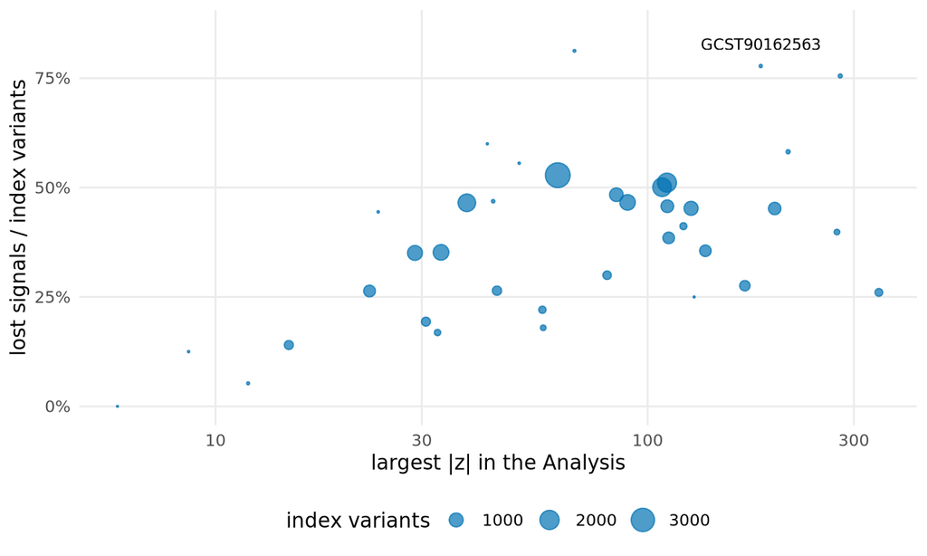

Lost signals per Analysis at D 0.5 cM, W 1 Mb against the Analysis’s largest |z| (log scale), r² 0.01. Analyses with strong peaks lose far more of plink2’s index variants, because r² 0.01 clumping keeps the shoulders of a strong peak as separate index variants. The labelled Analysis is the one discussed in the text.

The spikes matter little: at D 0.1 cM, W 2.5 Mb, 4 of 7,428 spurious splits and 0 of 5,929 lost signals span either spike.

#### The count judgement: C1 and C2 met, C3 not

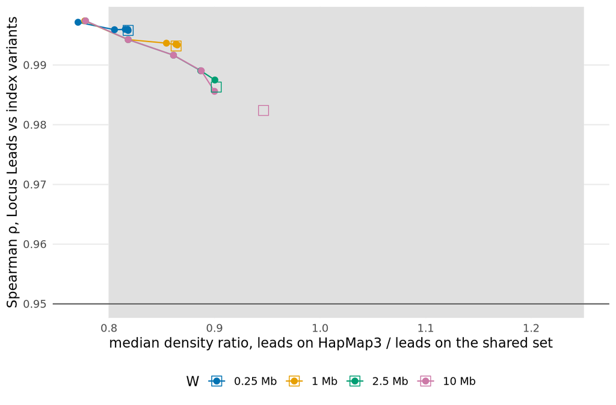

The count criteria at every (D, W) for the 37 EUR Analyses. C1 holds above the horizontal line (Spearman ρ ≥ 0.95); the shaded band is C2’s range for the median density ratio (C2’s second leg, on the median |log2|, is in the table below). Open squares are bp-only. Every point clears C1; only D 0.1 cM falls out of the band, and bp-only at W 10 Mb comes closest to finding as many loci on HapMap3 as on the full shared set.

- **C1 holds at 24 of 24 points**, with ρ from 0.982 to 0.997. Counting Locus Leads ranks Analyses as clumping does.
- **C2 holds at 20 of 24 points**; it fails only at D 0.1 cM. Raw rows keep a median of 0.176 of their count on HapMap3 (median |log2| 2.508), so C2 asks the leads’ median |log2| to be at most 1.254. Leads are far less density-sensitive than rows.
- **The point named is bp only, W 10 Mb**, which loses 4.8% of its leads when only HapMap3 variants are present. The best cM point is D 2.5 cM, W 10 Mb, which loses 9.3%.
- **C3 holds at no W**. The largest gain in ρ any cM point makes over bp-only at its W is +0.0150 (D 0.1 cM, W 10 Mb), against a margin of 0.01, and it costs 0.283 in median |log2|, against a margin of 0.1. The best |log2| gain any cM point makes is 0.002. In EUR, cM adds nothing the counts can see.

C3 at each W: the cM point that gains most in ρ over bp-only, and what it does to density sensitivity.

| W | bp-only ρ | bp-only median \|log2\| | cM point with the largest ρ gain | Δρ | Δ\|log2\| (positive is better) | C3 holds |
| --- | --- | --- | --- | --- | --- | --- |
| 0.25 Mb | 0.996 | 0.290 | 0.1 cM | +0.0014 | -0.086 | no |
| 1 Mb | 0.993 | 0.212 | 0.1 cM | +0.0042 | -0.152 | no |
| 2.5 Mb | 0.986 | 0.149 | 0.1 cM | +0.0111 | -0.213 | no |
| 10 Mb | 0.982 | 0.079 | 0.1 cM | +0.0150 | -0.283 | no |

### #404: other maps

**Question.** Is the published pyrho EUR map good enough, or would another map make a cM condition worth having? The same Analyses, shared set and grid were run with the **median** of the 5 EUR population maps (taken over rates per interval, which removes single-population spikes) and with **HapMap II**, lifted to GRCh38 as Eagle ships it.

**Criteria.** Each map’s best (D, W) and per-lead rates beside the pyrho mean’s, on the same rows; a statement of whether the pyrho map is adequate; checksums verified and cM non-decreasing for each map; the deCODE licence recorded. **Met**, with deCODE left out.

**deCODE.** The pedigree map from deCODE (Halldorsson et al., *Science*) was the first proposal’s default. Its file and its terms of use could not be reached from the build node (the publisher’s site answers with a bot challenge), and no open copy or licence was found, so the run left it out rather than guess at its terms. A pedigree map therefore remains untested.

**Result.** Every map leaves exactly the same shared set: 1,806,262 of 1,964,596 tier rows (91.9%), with one digest over all 40 drawn Analyses. None of the maps makes C3 hold at any W:

The EUR maps on #403’s Analyses, shared set and grid. The best per-lead point is #403’s: the qualifying (D, W) with the lowest disagreement or, when none qualifies, the one whose larger rate is smallest. Per-lead rates are at r² 0.01; the spike column is the cM each map puts across the intervals where the pyrho mean jumps.

| map | genetic length | C1 held at | C2 held at | C3 holds at | point named | its leads lost to density | best cM point (lost to density) | largest Δρ over bp-only | best per-lead point: spurious / lost | spurious / lost at D 0.5 cM, W 1 Mb | cM gained across the spike intervals | shared-set rows clamped at a map end |
| --- | --- | --- | --- | --- | --- | --- | --- | --- | --- | --- | --- | --- |
| pyrho-mean | 2,618.0 cM | 24 of 24 | 20 of 24 | no W | bp only, W 10 Mb | 4.8% | D 2.5 cM, W 10 Mb (9.3%) | +0.0150 | D 0.1 cM, W 2.5 Mb (none qualifies): 32.3% / 27.6% | 11.6% / 42.7% | chr7 18.601; chr1 6.762 | 1 |
| pyrho-median | 2,419.9 cM | 24 of 24 | 20 of 24 | no W | bp only, W 10 Mb | 4.8% | D 2.5 cM, W 10 Mb (9.0%) | +0.0141 | D 0.1 cM, W 2.5 Mb (none qualifies): 30.9% / 27.9% | 11.6% / 43.3% | chr7 0.084; chr1 0.058 | 1 |
| hapmap2 | 3,608.5 cM | 24 of 24 | 20 of 24 | no W | bp only, W 10 Mb | 4.8% | D 2.5 cM, W 10 Mb (10.5%) | +0.0160 | D 0.25 cM, W 1 Mb (none qualifies): 20.9% / 31.2% | 13.0% / 37.9% | chr7 0.055; chr1 0.085 | 325 |

- **The pyrho EUR map is adequate, and the map is not the lever.** Every map names the same point, bp only, W 10 Mb, where cM is not read at all.
- **The median removes both spikes** without changing the verdict.
- **HapMap II is 38% longer** in cM than the pyrho mean, so a given D covers fewer bp; it turns lost signals into spurious splits. Its largest ρ gain over bp-only is the biggest of the maps, and it still fails C3’s density margin.
- Rows outside a map’s first or last point take that point’s cM, held flat: HapMap II clamps 325 shared-set rows this way (155 before its first point, 170 after its last), the pyrho mean 1. Neither comparison map lost a point to the non-decreasing check (0 and 0 points dropped).

### #405: AFR, EAS and AMR

**Question.** Does the method work beyond EUR, and with what D per ancestry? It also tests the revision’s two predictions: AFR needs a smaller D than EUR, and the AMR map is the least trustworthy.

**Criteria.** For each ancestry: a seeded, recorded draw; the best (D, W) or why none qualifies; per-lead rates at both r²; D compared with EUR’s; the population weights recorded; whether the AMR map is usable. The same grid, count criteria and row cap as #403, each ancestry against its own map and panel, with seed 405.

Each ancestry’s sweep against its own map and panel. EUR’s column is #403’s.

| ancestry | Store | pool / drawn / swept | below the shared-set floor | tier rows swept | in the shared set | C1 held at | C2 held at | C1 and C2 | point named | C3 holds at | nearest per-lead point | spurious / lost there, r² 0.01 | spurious / lost there, r² 0.001 |
| --- | --- | --- | --- | --- | --- | --- | --- | --- | --- | --- | --- | --- | --- |
| EUR | OGS-00009, OGS-00011, OGS-00012 | 7,372 / 40 / 37 | 3 | 1,964,596 | 91.9% | 24 of 24 | 20 of 24 | 20 of 24 | bp only, W 10 Mb | no W | D 0.1 cM, W 2.5 Mb | 32.3% / 27.6% | 71.7% / 37.0% |
| AFR | OGS-00013 | 1,368 / 40 / 26 | 14 | 403,086 | 75.5% | 4 of 24 | 0 of 24 | 0 of 24 | none | 0.25 Mb, 1 Mb, 2.5 Mb, 10 Mb | D 0.1 cM, W 0.25 Mb | 40.4% / 46.7% | 68.9% / 27.3% |
| EAS | OGS-00015 | 241 / 40 / 30 | 10 | 3,529 | 95.2% | 24 of 24 | 12 of 24 | 12 of 24 | D 1 cM, W 1 Mb | no W | D 0.25 cM, W 0.25 Mb | 15.7% / 15.7% | 20.5% / 2.9% |
| AMR | OGS-00014 | 850 / 40 / 29 | 11 | 178,728 | 96.4% | 24 of 24 | 0 of 24 | 0 of 24 | none | 10 Mb | D 0.5 cM, W 1 Mb | 33.6% / 39.0% | 42.4% / 30.1% |

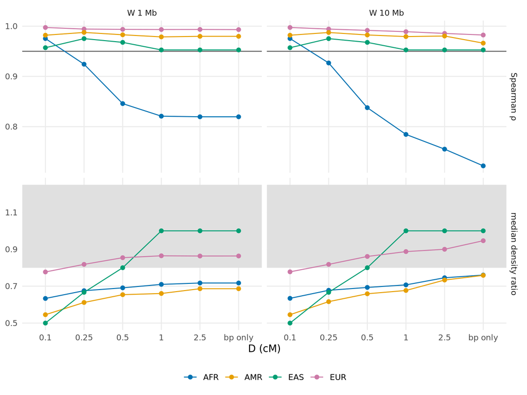

ρ (C1, top) and the median density ratio (C2, bottom) against D for each ancestry, at W 1 Mb and W 10 Mb; the right-most point is bp-only. Above the line is C1; inside the band is C2’s ratio range. EUR and EAS stay high on ρ and reach the band; AFR’s ρ collapses as D grows; AMR keeps its ρ but never reaches the band.

- **AFR: the prediction cannot be judged by counts.** AFR names no point: C1 holds at 4 of 24 points (all at D 0.1 cM) and C2 at 0. Both AFR’s and EUR’s nearest per-lead points sit at the grid’s smallest D, so a calibrated D for AFR would be at or below where the grid stops. What is observed fits the prediction without proving it: at W 1 Mb, AFR’s ρ falls from 0.975 at D 0.1 cM to 0.820 bp-only, where EUR’s goes from 0.997 to 0.993; at W 10 Mb AFR’s falls from 0.975 to 0.722. C3 holds at every W for AFR (W 0.25 Mb: D 0.1, 0.25 cM; W 1 Mb: D 0.25, 0.5 cM; W 2.5 Mb: D 0.5, 1 cM; W 10 Mb: D 2.5 cM), but on counts that C2 rejects.
- **AMR: usable to rank, not to choose D.** C1 holds at 24 of 24 points (ρ 0.966–0.990), but C2 at 0 of 24. The AMR panel has 345 samples, and 18.73% of its unlinked pairs reach r² 0.01 by chance, against 1.16% in EUR, so its clump counts are partly chance. Admixture’s long-range LD shows in the disagreements: at AMR’s nearest point, 86.0% of spurious splits lie more than 1 Mb from their clump’s index variant and 45.7% have r² of at least 0.05, where chance gives 1.04%. For EUR the same shares are 25.9% and 35.1%. No cM distance inside W separates such pairs.
- **EAS names D 1 cM, W 1 Mb,** where C1 and C2 hold, but C3 holds at no W: the named point ties bp-only at W 10 Mb exactly, on every count metric, and bp-only at W 10 Mb meets C1 and C2 itself (ρ 0.953, median ratio 1.000). The EAS verdict rests on 3,529 tier rows from 30 Analyses, none with largest |z| above 23.8, so treat it as indicative.

Chance LD, two ways. The panel’s own: 200,000 seeded cross-chromosome pairs of the shared-set variants the swept Analyses hold, a property of the panel’s sample size. Index pairs: cross-chromosome pairs of each swept Analysis’s own index variants, which depend on how many hits the Analyses have (EAS has few).

| panel | samples | pooled variants / used | panel: r² ≥ 0.001 | panel: r² ≥ 0.01 | panel: r² ≥ 0.05 | index pairs: r² ≥ 0.001 | index pairs: r² ≥ 0.01 | index pairs |
| --- | --- | --- | --- | --- | --- | --- | --- | --- |
| EUR | 771 | 950,809 / 3,000 | 42.0% | 1.16% | 0.001% | 42.3% | 1.24% | 13,814,474 |
| AFR | 804 | 140,181 / 3,000 | 44.3% | 1.70% | 0.008% | 43.8% | 1.55% | 1,342,319 |
| EAS | 817 | 1,536 / 1,536 | 41.7% | 1.40% | 0.002% | 33.7% | 2.17% | 92 |
| AMR | 345 | 65,168 / 3,000 | 66.7% | 18.73% | 1.043% | 60.0% | 12.27% | 197,937 |

### #406: what pruning costs

**Question.** Is genetic-distance pruning actually cheaper than clumping, the reason for considering it, and is it fast enough to run per query?

**Criteria.** Every number in the run’s output with the machine, date and commit; pruning against clumping as a ratio for the same Analyses; and whether query-time pruning of the largest slice is fast enough per query. The budget, fixed before measuring, was: pruning runs per query when its stages cost no more than the query they follow (fast_ratio <= 1), so the reader waits at most twice as long. **Met**; the answer to the last is no.

The run was on 2026-11-06, on Intel(R) Xeon(R) Platinum 8480+ (224 cores), at engine commit `421433f`, with 3 repeats of each stage, the rule at D 0.5 cM, W 1 Mb, and plink2 on 4 threads.

**Building the cM array.** For OGS-00011’s 48,069,918 variants, reading chromosome and position from the Store Variant Table took 21.7 s and interpolating cM 9.3 s. The per-variant chromosome, position and cM arrays together take 433 MB, the cM array alone 192 MB, and 1,525,683 variants on MT, X, Y have no cM.

#406 timed two workloads, and each table below holds one. **Per query** is the whole tier a Top-Hit Query returns, imputed rows included: this is what a per-query option would prune. **Against clumping** is the shared set of the same Analysis, the rows both methods can see: this is where pruning and clumping do the same job. Each ratio follows from the two times beside it.

Per query, on the whole tier: what pruning adds to the query it follows. Medians of the repeats. Pruning as written reads positions from the Store Variant Table; the block-at-a-time rule gives the same leads and reads per-variant position and cM arrays.

| slice | tier rows | Top-Hit Query | same query, resolved | pruning as written | ÷ query | block rule with per-variant arrays | ÷ query | ÷ resolved query |
| --- | --- | --- | --- | --- | --- | --- | --- | --- |
| OGS-00011 GCST004461 at 5×10<sup>−8</sup> | 9,429,671 | 2.65 s | 42.82 s | 29.67 s | 11.2× | 4.13 s | 1.56× | 0.096 |
| OGS-00011 GCST004461 at 5×10<sup>−4</sup> | 10,087,639 | 2.39 s | 47.52 s | 35.38 s | 14.8× | 4.60 s | 1.93× | 0.097 |
| OGS-00012 GCST90475362 at 5×10<sup>−4</sup> | 2,755,733 | 0.50 s | 14.82 s | 8.49 s | 17.0× | 1.87 s | 3.74× | 0.126 |
| OGS-00012 GCST90475362 at 5×10<sup>−8</sup> | 927,929 | 0.35 s | 4.06 s | 2.74 s | 7.9× | 1.17 s | 3.36× | 0.287 |
| OGS-00011 GCST90245992 at 5×10<sup>−8</sup> | 632,889 | 0.41 s | 3.38 s | 2.00 s | 4.9× | 1.13 s | 2.80× | 0.335 |
| OGS-00011 GCST002047 at 5×10<sup>−8</sup> | 2,314,363 | 0.88 s | 11.24 s | 6.69 s | 7.6× | 1.20 s | 1.37× | 0.107 |
| OGS-00003 finngen-r13-BMI_IRN at 5×10<sup>−8</sup> | 55,460 | 0.12 s | 0.50 s | 0.36 s | 3.0× | 0.24 s | 2.05× | 0.481 |

Against clumping, on the shared set of the same Analysis: pruning (the cM lookup and the rule) and clumping on the same rows. Clumping end to end includes matching the rows to the panel.

| slice | shared-set rows | pruning as written | block rule | plink2 alone | clumping, end to end | as written ÷ plink2 | block rule ÷ plink2 | block rule ÷ end to end |
| --- | --- | --- | --- | --- | --- | --- | --- | --- |
| OGS-00011 GCST004461 at 5×10<sup>−8</sup> | 3,527,954 | 7.56 s | 2.59 s | 11.31 s | 48.30 s | 0.669 | 0.229 | 0.054 |
| OGS-00011 GCST004461 at 5×10<sup>−4</sup> | 3,529,871 | 5.93 s | 1.77 s | 12.55 s | 51.60 s | 0.473 | 0.141 | 0.034 |
| OGS-00012 GCST90475362 at 5×10<sup>−4</sup> | 1,735,661 | 2.50 s | 1.57 s | 6.34 s | 38.94 s | 0.394 | 0.248 | 0.040 |
| OGS-00012 GCST90475362 at 5×10<sup>−8</sup> | 763,450 | 1.49 s | 1.10 s | 3.45 s | 35.34 s | 0.433 | 0.319 | 0.031 |
| OGS-00011 GCST90245992 at 5×10<sup>−8</sup> | 114,148 | 0.27 s | 0.86 s | 2.06 s | 25.52 s | 0.130 | 0.415 | 0.034 |
| OGS-00011 GCST002047 at 5×10<sup>−8</sup> | 2,245,120 | 3.64 s | 1.18 s | 8.06 s | 37.99 s | 0.452 | 0.147 | 0.031 |
| OGS-00003 finngen-r13-BMI_IRN at 5×10<sup>−8</sup> | 47,457 | 0.05 s | 0.22 s | 1.79 s | 31.37 s | 0.030 | 0.125 | 0.007 |

- **Against clumping, on the shared set, pruning is cheaper on every slice.** Divided by plink2 alone, the rule as written costs 0.030–0.669 of clumping’s time (1.5×–34× cheaper), and the block rule 0.125–0.415. Against clumping end to end, which must first match rows to the panel, the block rule is 19×–141× cheaper.
- **Per query, on the whole tier, it misses the budget on 7 of 7 slices.** #406 reported its budget on GCST004461’s 5×10<sup>−8</sup> tier (9,429,671 rows), where the Top-Hit Query takes 2.65 s. Pruning as written takes 29.67 s (11.2× the query), of which reading positions from the Store Variant Table takes 13.7 s, against 0.097 s from a per-variant array. The block rule with per-variant arrays takes 4.13 s (1.56× the bare query, but 0.096 of the resolved query a reader actually waits for, 42.8 s). The resolved query’s own peak memory was 12,737 MB, from 2,451 MB already resident. The largest slice by rows is its 5×10<sup>−4</sup> tier (10,087,639 rows): query 2.39 s, pruning as written 35.38 s (14.8×), block rule 4.60 s (1.93× the query, 0.097 of the resolved query).
- On every slice, the block rule gives the same leads as the rule as written.
- **Two of the timed Analyses are artefact-like:** the ones #403’s draw excludes by its row cap. At 5×10<sup>−8</sup>, GCST004461 has 3,652,412 of its 9,429,671 tier rows past |z| 38, and GCST002047 has 2,223,172 of its 2,314,363 tier rows past |z| 38. They are timed for cost only.

Absolute seconds carry the node’s load: its load average reached 30.8 during the run. The ratios and the share of each stage are what to compare.

### #409: boundaries from the data

**Question.** #403 showed that per-lead disagreement concentrates at strong peaks. Would locus boundaries taken from the data do better than a fixed distance? Two rules were tried on #403’s Analyses, shared set and clumps:

- **peak prominence:** two 5×10<sup>−8</sup> hits stay in one locus unless the |z| profile between them, read from the 5×10<sup>−4</sup> tier as the maximum |z| per bin of B bp, falls into a valley. A row joins the strongest accepted lead whose lowest bin between them stays above a threshold (relative, f × the row’s |z|, or a fixed chain of non-empty bins), and no merge spans more than the clumping window. B ∈ {10, 50} kb; thresholds f 0.25, f 0.5, f 0.75, fixed T 0.
- **one lead per LD block:** the strongest row in each of the 1,357 EUR LD blocks of the panel’s region file.

**Criteria.** C1 and C2 in #403’s wording (C2 restricts the profile to HapMap3 as well as the hits); C3’s margins against bp-only at W 10 Mb and at each other W; per-lead rates by the lead’s |z| band; every valley that separates two leads classed as low |z| or no tier row, with a sample checked against the Store. **Met.** At #403’s named point, W 10 Mb, neither rule beats distance pruning: C3 holds there for no rule. Elsewhere on the grid, B 50 kb, f 0.75 meets C3 at W 1 Mb (Δρ -0.009, density gain +0.113 in median |log2|).

The prominence and LD-block rules on #403’s 37 Analyses at r² 0.01, beside #403’s named point and the tracer’s point. Δ|log2| is positive when the rule is less density-sensitive than bp-only.

| rule | ρ | C1 | median density ratio | median \|log2\| | C2 | Δρ / Δ\|log2\| against bp-only, W 10 Mb | C3 holds at | spurious / lost | disagreement, leads with \|z\| ≥ 20 | Locus Leads in GCST90162563 (27 clumps) |
| --- | --- | --- | --- | --- | --- | --- | --- | --- | --- | --- |
| B 10 kb, f 0.25 | 0.942 | no | 1.684 | 0.794 | no | -0.040 / -0.714 | no W | 48.6% / 30.5% | 32.5% | 31 |
| B 10 kb, f 0.5 | 0.952 | yes | 1.600 | 0.725 | no | -0.031 / -0.645 | no W | 51.7% / 29.4% | 41.9% | 35 |
| B 10 kb, f 0.75 | 0.980 | yes | 1.274 | 0.467 | no | -0.003 / -0.387 | no W | 64.6% / 24.9% | 53.1% | 61 |
| B 10 kb, fixed T 0 | 0.945 | no | 1.686 | 0.789 | no | -0.038 / -0.710 | no W | 48.4% / 30.5% | 28.2% | 30 |
| B 50 kb, f 0.25 | 0.966 | yes | 1.000 | 0.127 | yes | -0.016 / -0.048 | no W | 10.7% / 50.0% | 17.3% | 8 |
| B 50 kb, f 0.5 | 0.972 | yes | 1.000 | 0.134 | yes | -0.010 / -0.054 | no W | 12.1% / 46.8% | 18.7% | 10 |
| B 50 kb, f 0.75 | 0.984 | yes | 0.962 | 0.098 | yes | +0.002 / -0.019 | W 1 Mb | 23.0% / 34.9% | 22.0% | 13 |
| B 50 kb, fixed T 0 | 0.966 | yes | 1.000 | 0.127 | yes | -0.016 / -0.048 | no W | 10.7% / 50.1% | 17.9% | 8 |
| LD blocks (EUR) | 0.990 | yes | 0.863 | 0.213 | yes | +0.008 / -0.133 | no W | 9.4% / 53.9% | 19.9% | 6 |
| #403 bp only, W 10 Mb | 0.982 | yes | 0.946 | 0.079 | yes |  |  | 1.6% / 83.0% | 23.0% | 3 |
| #403 D 0.5 cM, W 1 Mb | 0.994 | yes | 0.854 | 0.227 | yes |  |  | 11.6% / 42.7% | 17.9% | 8 |

- **C3 holds at W 10 Mb for no rule.** At any W it holds for B 50 kb, f 0.75 at W 1 Mb.
- **Narrow bins fail C2.** 0 of the 4 B 10 kb rules meet it (median ratio 1.27–1.69): on HapMap3 the profile has gaps that read as valleys, so the rule finds more loci on the sparse axis, not fewer.
- **LD blocks** rank well (ρ 0.990) but are more density-sensitive than bp-only (median |log2| 0.213 against 0.079). Rows outside every block are counted: 7 rows in 3 stretches.
- **At strong peaks** (leads with |z| ≥ 20), B 50 kb, f 0.25; B 50 kb, f 0.5; B 50 kb, fixed T 0; LD blocks (EUR) disagree with clumping clearly less often than bp-only at W 10 Mb. Against D 0.5 cM, W 1 Mb, no rule does.
- **Valleys are real, not gaps.** There are 33,248 distinct valleys with no tier row. In a sample of 200 per bin width checked against the Store, 13.5% (B 10 kb) and 0.5% (B 50 kb) are gaps in coverage rather than low |z|, so the stop rule, which withholds the judgement when gaps dominate a sample, did not trip.

#### Three regions, rule by rule

The counts above summarise whole genomes. Three regions show how they arise, lead by lead. #409’s `eur_regions.json` takes the Analysis its judgement names and one Analysis drawn from each other |z| band, and in each Analysis the 10 Mb window that holds the most index variants. Each caption gives the rule as the file records it.

**GCST90162563 (Vitamin D-binding protein levels, Store OGS-00011, largest |z| 182.6), chr4:66.95–74.84 Mb.** The view spans 7.89 Mb and holds 25 clumps, and they interleave. Clump 3 (index |z| 32.8, 11 members) runs from 67.25 Mb to 72.99 Mb, across the peak at 71.75 Mb. Clump 2’s index variant (|z| 39.0) lies 44,836 bp from the peak’s, and no rule keeps a lead for it. In this view bp-only keeps 1 lead and loses 24 index variants, the cM point 1 lead and 24, one lead per LD block 4 leads and 21, and prominence 7 leads and 19. Prominence’s lead at 73.62 Mb is a spurious split inside clump 1, the peak’s own LD shadow.

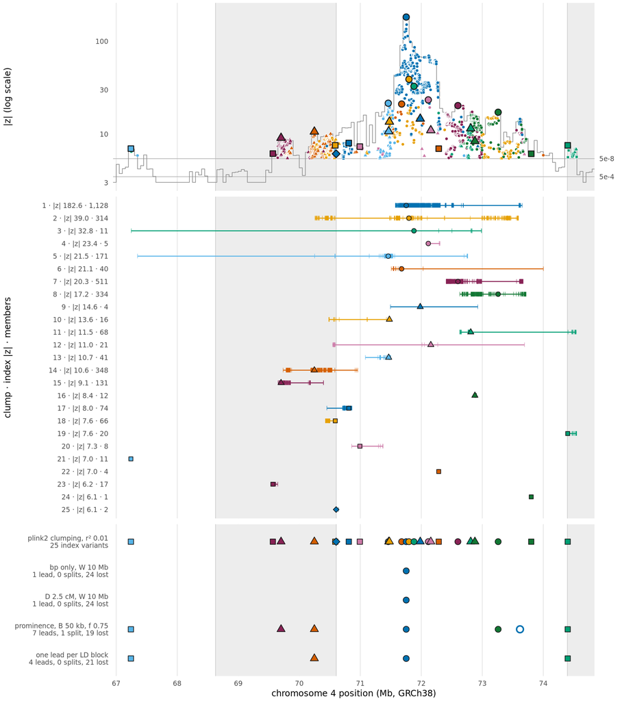

GCST90162563 (Vitamin D-binding protein levels, Store OGS-00011, largest |z| 182.6), chr4:66.95–74.84 Mb. It is the Analysis #409’s judgement names. As eur_regions.json records the rule, the window is the 10,000,000 bp window [p, p + 10,000,000) starting at one of the Analysis’s index variants that holds the most index variants; ties go to the first in genome order (chromosome 1-22 by number, then others by name, then position); the view is the window’s shared-set rows from first to last, padded by 4% of that span (at least 20,000 bp) each side, never below 0. Top: each point is a 5×10<sup>−8</sup> row of the shared set, coloured by the r² 0.01 clump plink2 puts it in (colours repeat after 8 clumps with a new marker shape); outlined points are index variants, so points of one colour far from their outlined point are that clump’s LD shadow. The grey step line is the prominence profile, the largest |z| of the 5×10<sup>−4</sup> rows in each 50 kb bin, the thin lines mark |z| at 5×10<sup>−8</sup> and 5×10<sup>−4</sup>, and alternate shading marks the EUR LD blocks. Middle: one lane per clump, strongest at the top, drawn from its westmost to its eastmost member on the chromosome and labelled with its index variant’s |z| and its members; lanes that overlap are clumps interleaved along the chromosome. Bottom: where plink2 and each rule put their leads in the view, coloured by clump. A filled marker is also a plink2 index variant and a hollow one is a spurious split; a clump with no marker in a rule’s row was merged into a stronger lead. The counts are for this view only. 702 of the 4,060 5×10<sup>−8</sup> rows in the view are not drawn: they are not in the shared set (all absent from the panel at their position), so plink2 never clumped them. The largest |z| among them is 34.0, and the profile, which reads every observed row, includes them, so it can peak above the drawn points.

**GCST90319613 (Serum glycated hemoglobin levels, Store OGS-00011, largest |z| 57.1), chr17:75.54–83.35 Mb.** Its two strongest clumps, index |z| 22.2 at 78.13 Mb and 20.6 at 82.73 Mb, lie 4.60 Mb apart, within one W of 10 Mb, and bp-only merges the second into the first’s lead. In this view bp-only keeps 1 lead and loses 8 index variants, the cM point 3 leads and 6, one lead per LD block 3 leads and 6, and prominence 4 leads and 5.

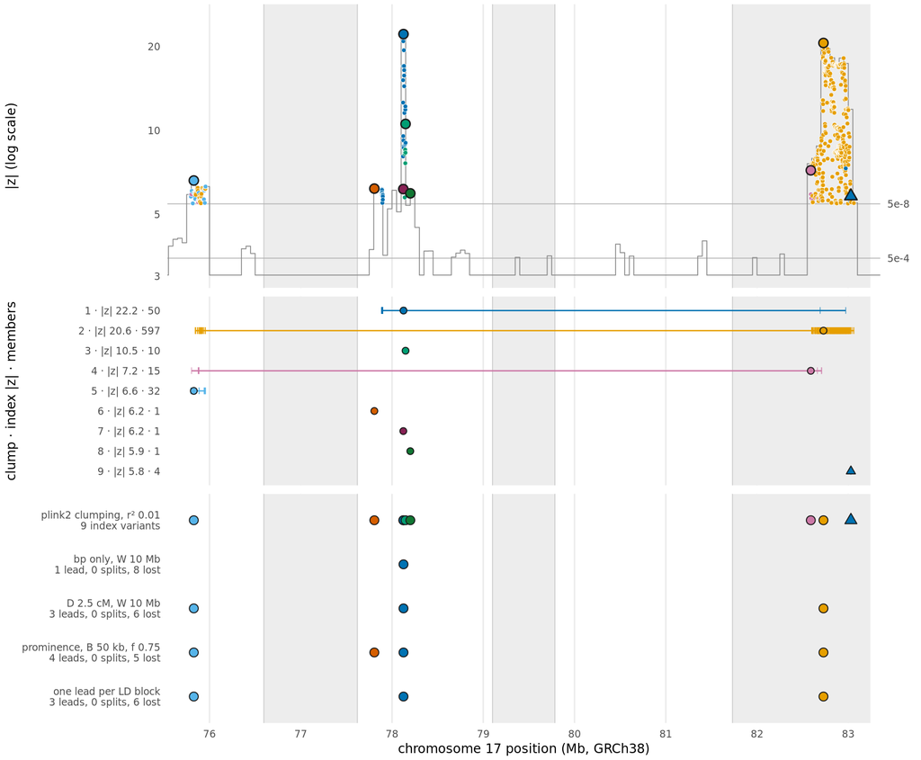

GCST90319613 (Serum glycated hemoglobin levels, Store OGS-00011, largest |z| 57.1), chr17:75.54–83.35 Mb. It was drawn with seed 62 from the 8 Analyses with largest |z| 38.5–100 and at least 27 index variants. As eur_regions.json records the rule, the window is the 10,000,000 bp window [p, p + 10,000,000) starting at one of the Analysis’s index variants that holds the most index variants; ties go to the first in genome order (chromosome 1-22 by number, then others by name, then position); the view is the window’s shared-set rows from first to last, padded by 4% of that span (at least 20,000 bp) each side, never below 0. Top: each point is a 5×10<sup>−8</sup> row of the shared set, coloured by the r² 0.01 clump plink2 puts it in (colours repeat after 8 clumps with a new marker shape); outlined points are index variants, so points of one colour far from their outlined point are that clump’s LD shadow. The grey step line is the prominence profile, the largest |z| of the 5×10<sup>−4</sup> rows in each 50 kb bin, the thin lines mark |z| at 5×10<sup>−8</sup> and 5×10<sup>−4</sup>, and alternate shading marks the EUR LD blocks. Middle: one lane per clump, strongest at the top, drawn from its westmost to its eastmost member on the chromosome and labelled with its index variant’s |z| and its members; lanes that overlap are clumps interleaved along the chromosome. Bottom: where plink2 and each rule put their leads in the view, coloured by clump. A filled marker is also a plink2 index variant and a hollow one is a spurious split; a clump with no marker in a rule’s row was merged into a stronger lead. The counts are for this view only. 13 of the 724 5×10<sup>−8</sup> rows in the view are not drawn: they are not in the shared set (11 absent from the panel at their position and 2 with other alleles than the panel’s), so plink2 never clumped them. The largest |z| among them is 16.9, and the profile, which reads every observed row, includes them, so it can peak above the drawn points.

**GCST90239826 (Free testosterone levels, Store OGS-00011, largest |z| 32.6), chr17:7.13–8.04 Mb.** Its 9 clumps lie within 0.91 Mb, inside one EUR LD block. Every rule keeps 1 lead and loses 8 index variants: none of them separates the clumps that plink2 keeps apart.

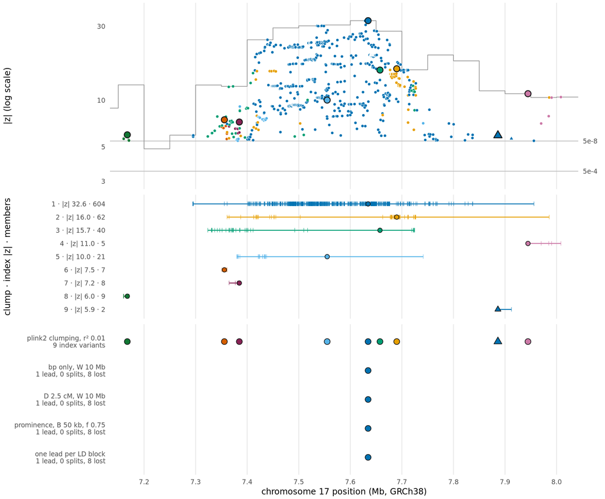

GCST90239826 (Free testosterone levels, Store OGS-00011, largest |z| 32.6), chr17:7.13–8.04 Mb. It was drawn with seed 62 from the 7 Analyses with largest |z| < 38.5 and at least 27 index variants. As eur_regions.json records the rule, the window is the 10,000,000 bp window [p, p + 10,000,000) starting at one of the Analysis’s index variants that holds the most index variants; ties go to the first in genome order (chromosome 1-22 by number, then others by name, then position); the view is the window’s shared-set rows from first to last, padded by 4% of that span (at least 20,000 bp) each side, never below 0. Top: each point is a 5×10<sup>−8</sup> row of the shared set, coloured by the r² 0.01 clump plink2 puts it in (colours repeat after 8 clumps with a new marker shape); outlined points are index variants, so points of one colour far from their outlined point are that clump’s LD shadow. The grey step line is the prominence profile, the largest |z| of the 5×10<sup>−4</sup> rows in each 50 kb bin, the thin lines mark |z| at 5×10<sup>−8</sup> and 5×10<sup>−4</sup>, and alternate shading marks the EUR LD blocks. Middle: one lane per clump, strongest at the top, drawn from its westmost to its eastmost member on the chromosome and labelled with its index variant’s |z| and its members; lanes that overlap are clumps interleaved along the chromosome. Bottom: where plink2 and each rule put their leads in the view, coloured by clump. A filled marker is also a plink2 index variant and a hollow one is a spurious split; a clump with no marker in a rule’s row was merged into a stronger lead. The counts are for this view only. 118 of the 876 5×10<sup>−8</sup> rows in the view are not drawn: they are not in the shared set (115 absent from the panel at their position and 3 with other alleles than the panel’s), so plink2 never clumped them. The largest |z| among them is 30.6, and the profile, which reads every observed row, includes them, so it can peak above the drawn points.

## What it means for `n_loci_*`

On 7 November 2026, after reading this report, the owner decided:

- **Locus Leads are dropped.** No pruning rule ships: not bp-only, not a cM limit, not peak prominence and not LD blocks. That holds for `n_loci_*` and for any option that would stand in for clumping. This page stays on the stores site as the reference write-up of the experiment.
- **`n_loci_*` will come from LD clumping at Store build time.** Each Store records the reference panel, the clumping window in kb, the p and r² thresholds, and the software version. OpenGWAS request logs will choose which configurations are stored.

This replaces an earlier decision, taken on the counts alone, to use bp-only at W 10 Mb for EUR and EAS. With no pruning shipped, the question of whether it would run only at build time or also per query no longer arises. The reasons follow.

**No rule agrees with clumping lead by lead.** #403’s per-lead criteria allow at most 10% spurious splits and at most 10% lost signals at r² 0.01. None of #403’s 24 (D, W) points stays within both; the nearest, D 0.1 cM, W 2.5 Mb, has 32.3% spurious splits and 27.6% lost signals. #409’s rules do no better: none of its 9 stays within both, and the nearest, prominence at B 50 kb, f 0.75, has 23.0% spurious splits and 34.9% lost signals.

**The bp-only count saturates.** The bp-only rule keeps one chromosome’s leads more than W apart, so a chromosome of L bp holds at most ⌊(L − 1) / (W + 1)⌋ + 1 of them. On the GRCh38 lengths the EUR panel’s variant tables record, the 22 chromosomes the map covers hold at most 300 leads at W 10 Mb, however many loci an Analysis has. Of the 37 Analyses, 19 have more clumps than that, from 327 to 3,419, yet bp-only finds only 114 to 206 Locus Leads in them. The most polygenic, GCST90476460, has 3,419 clumps: bp-only finds 206 Locus Leads; D 2.5 cM, W 10 Mb finds 605; one lead per LD block finds 1,184; and prominence at B 50 kb, f 0.75 finds 2,537. bp-only’s ρ of 0.982 does not show this, because ρ compares only ranks.

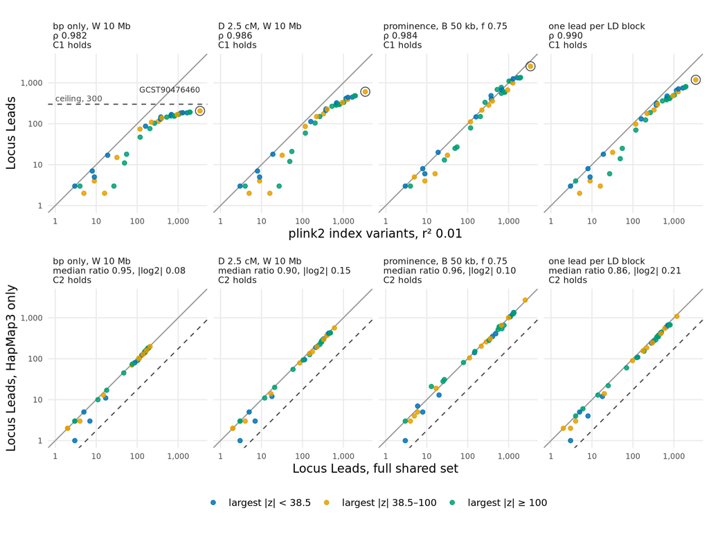

One point per EUR Analysis (37), coloured by its largest |z|, for the four rules the outcome weighs; both axes are logarithmic. Top row: each rule’s Locus Leads against plink2’s index variants at r² 0.01. On the grey diagonal a rule counts as many loci as clumping does, and ρ is Spearman’s rank correlation, which C1 asks to be at least 0.95. The dashed line in the bp-only panel is that rule’s ceiling at W 10 Mb, 300 leads: bp-only flattens below it as the clump count grows, while the other rules keep rising. The ringed Analysis, labelled in the bp-only panel, has the most clumps. Bottom row: each rule’s Locus Leads on HapMap3 variants only against its Locus Leads on the full shared set, the picture behind C2. A rule insensitive to variant density stays on the diagonal; the dashed line is where it would sit if it lost as much as the rows do (median ratio 0.18). All four rules stay near the diagonal.

**The leads are not independent enough for Mendelian randomization (MR).** A spurious split is a Locus Lead that plink2 places inside a stronger index variant’s clump: at r² 0.01, it is in LD with a stronger signal. Prominence at B 50 kb, f 0.75 makes 23.0% of its Locus Leads spurious splits, and one lead per LD block 9.4%. bp-only (1.6%) and D 2.5 cM, W 10 Mb (3.6%) split less because they merge more: they lose 83.0% and 67.3% of the index variants. MR instruments are conventionally clumped at r² 0.001, a stricter bar than r² 0.01, so a Locus Lead in LD with a stronger one would count one signal twice.

**Exact clumping is affordable at build time.** #406 clumped GCST004461, the Analysis with the largest 5×10<sup>−8</sup> tier in the Stores, with plink2. On that tier’s shared set (3,527,954 rows) the whole bill was 48.30 s: 36.35 s to build the shared set, which matches the rows to the panel, 11.31 s for plink2 itself, and the rest to rank the rows. On its 5×10<sup>−4</sup> tier (3,529,871 rows) the bill was 51.60 s, of which the shared set took 38.39 s and plink2 12.55 s. A Store pays this once per Analysis, tier and configuration while it is built, and no query waits for it.

### The alternatives, as measured

The rules beside one another, on the count criteria, the per-lead rates and what each would need in a Store:

The rules the prototype measured, on #403’s 37 EUR Analyses. None ships: `n_loci_*` will come from LD clumping at Store build time.

| rule | ρ (C1) | median \|log2\| (C2) | leads lost to density | C3 holds at | spurious / lost at r² 0.01 | what it needs |
| --- | --- | --- | --- | --- | --- | --- |
| #403’s named point: bp only, W 10 Mb | 0.982 | 0.079 | 4.8% | (the baseline) | 1.6% / 83.0% | positions only |
| #403’s best cM point: D 2.5 cM, W 10 Mb | 0.986 | 0.152 | 9.3% | no W | 3.6% / 67.3% | a per-variant cM array |
| the tracer’s point: D 0.5 cM, W 1 Mb | 0.994 | 0.227 | 15.3% | no W | 11.6% / 42.7% | a per-variant cM array |
| one lead per LD block | 0.990 | 0.213 | 12.2% | no W | 9.4% / 53.9% | an LD-block file per ancestry |
| prominence, B 50 kb, f 0.75 | 0.984 | 0.098 | 4.3% | W 1 Mb | 23.0% / 34.9% | the 5×10<sup>−4</sup> tier as a profile |

## Limitations

- **Small panels and chance LD.** The reference is clumping on panels of 771 (EUR) down to 345 (AMR) samples. At these sizes 42% of unlinked EUR pairs reach r² 0.001 and 18.7% of unlinked AMR pairs reach r² 0.01. Clump counts are themselves noisy at low r², which is why the counts are judged at r² 0.01 and AMR is not calibrated.
- **EAS is thin.** 30 Analyses and 3,529 tier rows, from a pool of 241 in which 158 have no Observed Association at 5×10<sup>−8</sup>, and 0 have a largest |z| of 100 or more. Its C2 verdict may not survive a larger draw.
- **AFR’s panel fit.** 14 of 40 drawn AFR Analyses fell under the shared-set floor: 5 keep 68.1%–69.3% of their rows, and 9 keep at most 8.3%. The missing rows are rare variants below the AFR panel’s minor-allele-count filter, so the panel, not the matching, limits AFR.
- **Artefact Analyses excluded.** GCST002047 and GCST004461 exceed #403’s row cap of 1,000,000 observed rows, and 96% and 39% of their tier rows, respectively, lie past |z| 38. They are left out of every sweep and timed only for cost.
- **Load on the timing node.** #406’s absolute times carry a load average of up to 30.8; compare its ratios, not its seconds.
- **The draw is the committed one.** The EUR selection was drawn on the Store inventory of 2026-11-05. Drawing again today lists OGS-00024, OGS-00025 and OGS-00026 among the Stores left out (signals-only or cis coverage); the pool and the chosen Analyses are unchanged.
- **Untested.** A pedigree map (deCODE) and D below 0.1 cM for AFR were not run, and #406 did not time the bp-only rule itself.
- **The ceiling is an upper bound.** It lets a lead sit anywhere along a chromosome, including stretches where the panel has no variant, so the most bp-only can reach may be lower.

## Reproduce

This page reads two files, `docs/data/locus-leads-prototype.json` and, for the rows the region figures draw, `docs/data/locus-leads-regions.tsv`. Both are written by `tools/locus_leads_prototype_extract.py` from the engine’s committed outputs at `3c2bdd930423e301dea1419f76c5b4f986f4c8d0` (opengwas/opengwasdb, branch `orch/62-locus-leads`). The extract reads each output with `git show` and records its sha256. Where a later ticket’s output copies #403’s numbers (#404’s record of the pyrho mean, #409’s baselines, rows, criteria and per-Analysis records), every field the copy shares with #403’s output must be equal, at any depth; so must #405’s grid and criteria, each sweep’s selection digest, the panel sizes, and each ratio #406 publishes against the two times it divides. #403’s sweep and #409’s profile must give every Analysis the same index variants, and each ρ, median ratio and median |log2| recomputed from the per-Analysis counts must equal the one its output committed. The regions file must have read those same outputs, map, HapMap3 list, LD blocks and panel tables, and must give each of its Analyses the whole-genome index variants the per-Analysis records give it, with no rule holding more leads in a view than in the whole genome. An output the engine commit does not hold is refused too. Otherwise the extract refuses, naming the field and both values, and writes nothing. `tests/locus-leads-extract/` tests these refusals on synthetic outputs. A re-run at the same commit reproduces the extract byte for byte, and so does the TSV, whose sha256 the extract records.

The bp-only ceiling is the one input that is not an engine output. Its chromosome lengths come from the `##contig` headers of the EUR panel’s variant tables, at the path #403’s sweep names (`/data/opengwasdb/reference/hgdp1kgp-hg38/pgen/EUR`, on the build node), read with the `zstd` the `dev` environment ships; each header must name its chromosome and the panel’s assembly, gnomAD_GRCh38.

```bash
pixi run -e dev python3 tools/locus_leads_prototype_extract.py \
    --engine <an opengwasdb checkout holding the commit> --commit 3c2bdd9 \
    --output docs/data/locus-leads-prototype.json \
    --regions-rows docs/data/locus-leads-regions.tsv
# docs/ is a Quarto project whose pre-render belongs to the site build, so the
# page is rendered from a copy outside it and installed:
out=<a scratch directory>; mkdir -p "$out/reports" "$out/data"
cp docs/reports/locus-leads-prototype.qmd "$out/reports/"
cp docs/data/locus-leads-prototype.json docs/data/locus-leads-regions.tsv "$out/data/"
pixi run -e docs quarto render "$out/reports/locus-leads-prototype.qmd" --to html
cp "$out/reports/locus-leads-prototype.html" docs/locus-leads-prototype.html
```

The engine’s own commands for each output are in `prototypes/locus_leads/README.md` and in each per-ticket report under `docs/benchmark-output/locus_leads/`.

The engine outputs this page reads, under docs/benchmark-output/locus_leads/ at 3c2bdd9.

| output | ticket | bytes | sha256 |
| --- | --- | --- | --- |
| `OGS-00003_finngen-r13-BMI_IRN.json` | #402 | 189,152 | `50e115b1d01cb5d5da5bce21cb7eb0a5addc8b2641603af615845b47b41789de` |
| `eur_sweep.json` | #403 | 6,400,993 | `bf7307d2debc2b70cd12ffb4ff3b111aa9c535c1be48e674e40f216e2c2874b1` |
| `eur_sweep_selection.json` | #403 | 328,728 | `753e6d8cd6b517b4ce64d548ecf76602b7cbaf7c664cb70bd1aea95fe27f92c9` |
| `eur_maps.json` | #404 | 225,940 | `19920229e36222be311acb397bf5f539b9f9820948bdb8d7afb42becd0ed2701` |
| `ancestries_chance_ld.json` | #405 | 6,518 | `09802ffa6a780df832eb8a615dd62689c25c13b50f834aaf125ce437c9e7b131` |
| `ancestries_afr_sweep.json` | #405 | 4,346,620 | `84ad4eed53d8420ce292bc3a1de076b8ade44e70a5541d31585dc27186acb775` |
| `ancestries_afr_selection.json` | #405 | 15,357 | `95dde19c2fe17805e45ca29ce3167b93cca8c933bb2ba7362bedf82f97a51b57` |
| `ancestries_eas_sweep.json` | #405 | 4,879,451 | `7735071ac957508d96a8d6bf298ab71ef2b9d53d2b6f6c89e757b5c2ba426e45` |
| `ancestries_eas_selection.json` | #405 | 33,924 | `401ec596726eaaed68943a9742bba4e4cbf8877d0f0566d658e2bda7a1c72bb7` |
| `ancestries_amr_sweep.json` | #405 | 4,805,415 | `61b3b972f62e61961ee16e8861a4fdcc310e5db16bc44166c164c472952016cb` |
| `ancestries_amr_selection.json` | #405 | 14,706 | `47f979bbd5119fd56027b7430b00bcfff6863666060d8897786e0bf9fb40e6f2` |
| `cost.json` | #406 | 307,951 | `b1abd96591a803f88e4c0ecb22f73ff8368921d869c5abae8e10330e693a1971` |
| `eur_profile.json` | #409 | 639,805 | `ef836d52c1882eb1d36055eb3908f93fbca66b5c25a72255ef1575817f1e5e34` |
| `eur_regions.json` | #409 | 303,531 | `425d1b9d1752de5de67c7bef774a9f2ee58dd65cb26f565b31b49b030479a579` |

The panel variant tables the bp-only ceiling reads its chromosome lengths from, under /data/opengwasdb/reference/hgdp1kgp-hg38/pgen/EUR.

| chromosome | length (bp) | variant table | bytes | sha256 |
| --- | --- | --- | --- | --- |
| 1 | 248,956,422 | `chr1.pvar.zst` | 6,347,914 | `cef2b26ce96711bafc0c6987f3c05117e2583eca156c5c8c246595116fa7d757` |
| 2 | 242,193,529 | `chr2.pvar.zst` | 6,644,425 | `d59e464cd785e67cced793ff5d86313410aa45b1ef016c5d6a8efd061dd77350` |
| 3 | 198,295,559 | `chr3.pvar.zst` | 5,564,797 | `aa28bbaa20e1b60cbd85b16967dc281c8c8c9522c2bedd0dd51ab6e5ca293980` |
| 4 | 190,214,555 | `chr4.pvar.zst` | 5,701,111 | `f68d07238312e24a7947ef6d64e0021b668a836fea2b56e0058ecfd36db31648` |
| 5 | 181,538,259 | `chr5.pvar.zst` | 4,948,373 | `559744e435de5cdecb5443f2f049b523c51d9c8cee4941fb424dcde02448b7af` |
| 6 | 170,805,979 | `chr6.pvar.zst` | 5,356,138 | `b6e7f5a9786920fa22bfb4f9aa0500a4befe4b1376c2272bce073d712a61f875` |
| 7 | 159,345,973 | `chr7.pvar.zst` | 4,886,350 | `9f4d98b79b18536df25a18a9039d4b2a5ad9a0ee91208d425480ce6d64393fd4` |
| 8 | 145,138,636 | `chr8.pvar.zst` | 4,220,070 | `39a8c8215ecf53c78d4a4130486340396bd184b445e5d460f607ea58b0099066` |
| 9 | 138,394,717 | `chr9.pvar.zst` | 3,800,607 | `dadfe6366f6add204ac35d7f8464a62035f8ad56fe9115b78df7f6893991d7bc` |
| 10 | 133,797,422 | `chr10.pvar.zst` | 4,273,732 | `ace058fad8a041749b6702b288627214db89909fdd66294795e9e3c8c6346c97` |
| 11 | 135,086,622 | `chr11.pvar.zst` | 3,925,886 | `cda99e0a380946a102100b369d35d959b49e214e96e10fb4d8edd66ebd2d3559` |
| 12 | 133,275,309 | `chr12.pvar.zst` | 3,887,478 | `dd6386a5f16e78e1f4c341bed08d419e3c5c4878ee459da43213fdd677ddb364` |
| 13 | 114,364,328 | `chr13.pvar.zst` | 2,927,691 | `4b0ea0efb1b519b7684cc2c73fe3201bab85477e11f919427e21d41c3cbc8d0b` |
| 14 | 107,043,718 | `chr14.pvar.zst` | 2,675,575 | `a9b95511cea1724e5b7ba24e2f77ba337cbd7918803971df6c4aafafa5fb01f9` |
| 15 | 101,991,189 | `chr15.pvar.zst` | 2,456,505 | `b329613d647dc499243c5ffb517bd8dd9a16853867512aa5f6b8442e3130e4c3` |
| 16 | 90,338,345 | `chr16.pvar.zst` | 2,584,892 | `678d2451bc0aab2683d6c90cc8247f1e31c78a4c52ccc6fc2774b32cce64b223` |
| 17 | 83,257,441 | `chr17.pvar.zst` | 2,434,474 | `2890ad27649a154c01222140502dd6718b6e391f5585f99552bdbdac420e7388` |
| 18 | 80,373,285 | `chr18.pvar.zst` | 2,245,732 | `d6374e0f8c5cd506e0ba5b2683fcfb8b13d37812d31c6a100ec8edb9c6ff41ac` |
| 19 | 58,617,616 | `chr19.pvar.zst` | 2,081,863 | `09db4d81d50a138c73aba89be4f6cfee347c963fa89f952a52f9271df8884890` |
| 20 | 64,444,167 | `chr20.pvar.zst` | 1,917,108 | `a943c1b9a808e1a2ef1e38f6459438de48f50049dfe538df972b0a1b5b2b4f1c` |
| 21 | 46,709,983 | `chr21.pvar.zst` | 1,476,675 | `f6acbb9386b5b9d3b84d8e2cd7f51a5480890bc304c3858e2fe6d6e219db515a` |
| 22 | 50,818,468 | `chr22.pvar.zst` | 1,545,285 | `dd64ab3027559d0ebc3c8482a6eb1c8082deedb90f52d2ccfc85b9898bbdf5b0` |